# Intro to Phylogenetics Using Nextstrain

Day 4 of Training Workshop

Norman Hassell

# Disclaimer

- The findings and conclusions in this presentation are those of the authors and do not necessarily represent the official position of the Centers for Disease Control and Prevention.
- Use of trade names and commercial sources is for identification only and does not imply endorsement by the U.S. Department of Health and Human Services.
- References to non-CDC sites on the Internet do not constitute or imply endorsement of these organizations or their programs by CDC or the U.S. Department of Health and Human Services. CDC is not responsible for the content of pages found at these sites.

# Section 1: Overview

## Getting Started

Before we get started, let’s confirm your computer has `nextstrain` setup properly. Open a terminal and run the following command:

```bash
nextstrain setup --set-default conda
```

You should see the following output:

```
Checking setup…
✔ yes: operating system is supported
✔ yes: runtime data dir doesn't have spaces
✔ yes: runtime appears set up
✔ yes: snakemake is installed and runnable
✔ yes: augur is installed and runnable
✔ yes: auspice is installed and runnable

Setting default runtime to conda.

All good!  Set up of conda complete.
```

## Getting Started (Cont.)

If you ran into an error when running the command, go to the following [website](https://docs.nextstrain.org/en/latest/install.html#installation-steps).

Install the `nextstrain-cli` using the instructions for your operating system.

For the “Set up a Nextstrain runtime” section, follow the “Conda” instructions for your operating system. We’ll go around to help if you are running into issues.

## Getting Started (Cont.)

Before I move on we’ll be going through the first part of the practical [downloading data from GISAID to use in our analysis.](https://github.com/nhassell/seasonal-flu-demo/blob/master/demo.md#gisaid-file-custom-demo)

## Intro to the Intro

**Phylogenetics** is the study of evolutionary relationships among organisms.

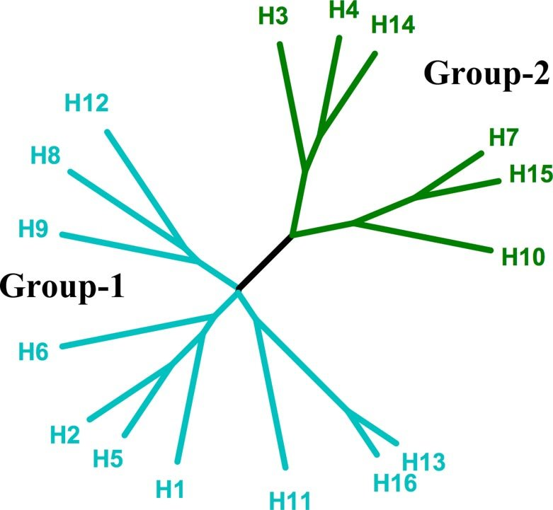

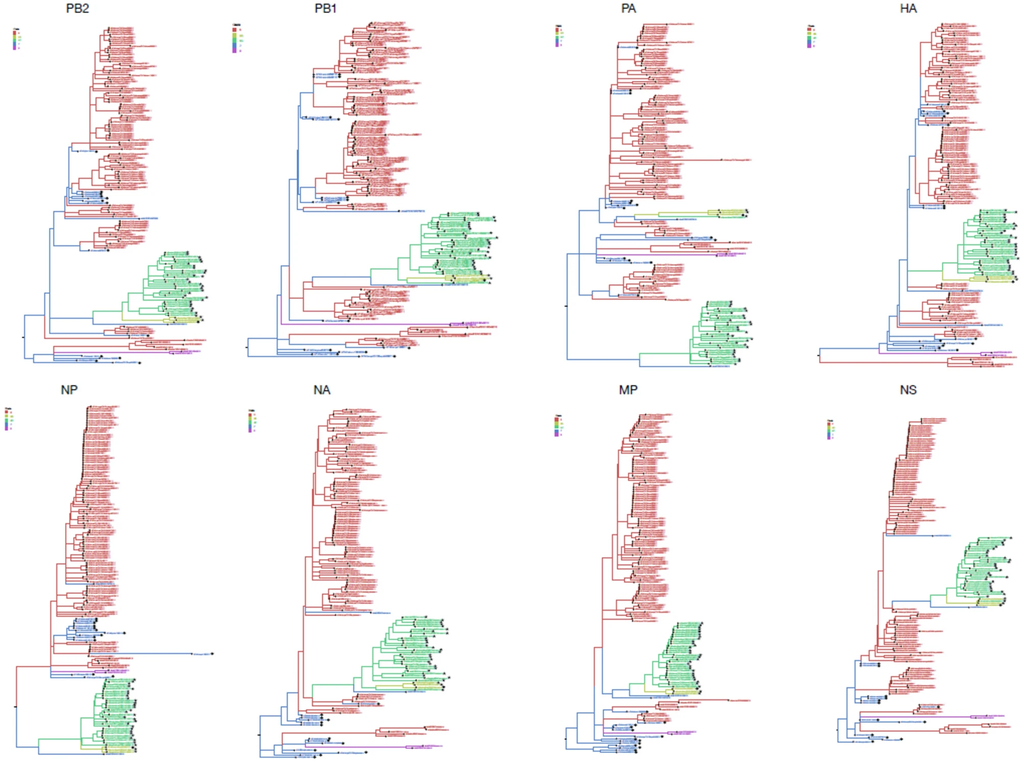

## Basic Components of a Phylogenetic Tree (Tips)

```r
library(ape)
library(ggtree)
library(ggplot2)
library(dplyr)

`%notin%` <- Negate(`%in%`)

# Branch lengths are explicit so we can display them
tree_text <- "((A:1,B:0.5,(C:1.5,D:0.5):0.5):0.5,E:0.5);"
tree <- read.tree(text = tree_text)
tree <- ape::root(tree, "E")

# Basic ggtree base plot
base_plot <- ggtree(tree, branch.length = "branch.length") + theme_tree2()

tips_plot <- base_plot +
  geom_tiplab(offset = 0.02) +        # tip labels
  geom_tippoint(size = 3, shape = 21, fill = "red", colour = "black") +  # highlight tips
  ggtitle("Tips highlighted")

tips_plot
```

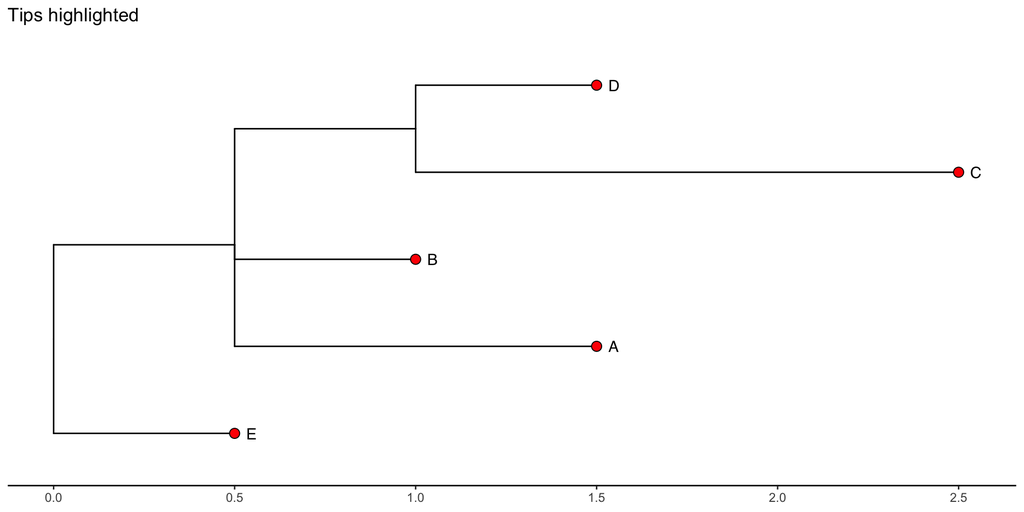

## Basic Components of a Phylogenetic Tree (Nodes)

```r
nodes_plot <- base_plot +
  geom_tiplab(offset = 0.02) +
  # mark internal (non-tip) nodes: use aes(subset = !isTip)
  geom_point2(aes(subset = !isTip), size = 3.5, shape = 21, fill = "green", colour = "black") +
  ggtitle("Nodes highlighted")

nodes_plot
```

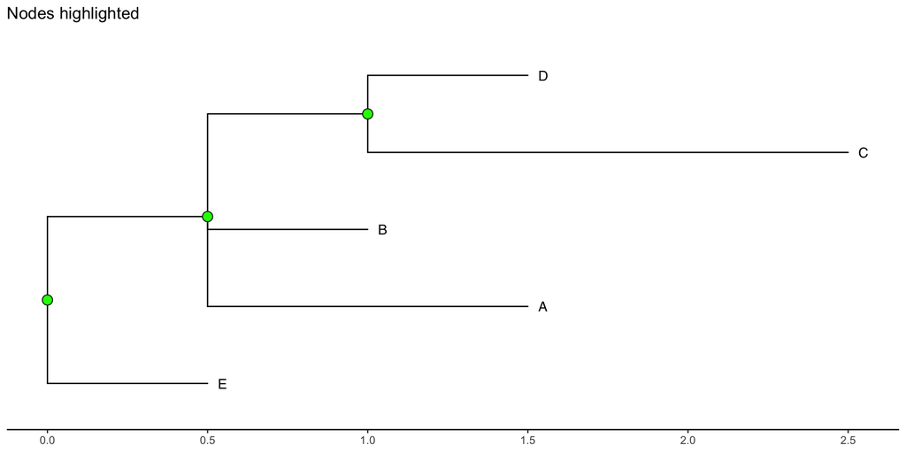

## Basic Components of a Phylogenetic Tree (Branches)

```r
branches_plot <- base_plot +
  geom_tiplab(offset = 0.02) +
  # place branch-length labels along branches; use aes(label=branch.length)
  # round to two decimals for display
  geom_label(aes(x = branch, label = round(branch.length, 2)), color = "red") +
  # emphasise branches visually by increasing line width (optional)
  # geom_segment2(aes(subset = !isTip), size = 1.2) +
  ggtitle("Branch lengths labeled (highlighted)")

branches_plot
```

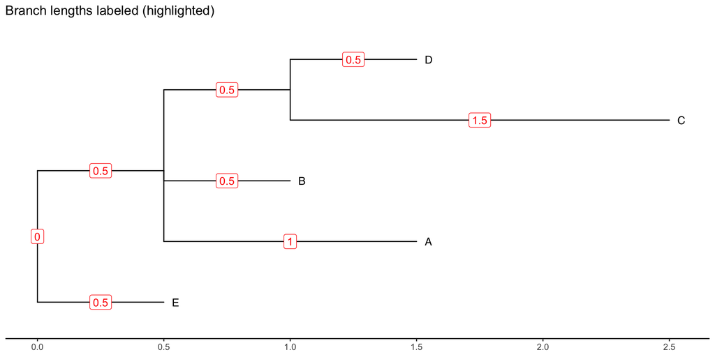

## Basic Components of a Phylogenetic Tree (Root)

```r
Ntip <- length(tree$tip.label)
root_node <- Ntip + 1

tree_df <- fortify(tree) %>%
  mutate(branch_color = case_when(label == "E" ~ "purple",
                              .default = "black"))

root_plot <- ggtree(tree_df, aes(color=I(branch_color))) + theme_tree2() +
  geom_tiplab(offset = 0.02) +
  # mark the root with a star or large point
  geom_point2(aes(subset = (node == !!root_node)), shape = 8, size = 5, colour = "purple") +
  # optionally annotate "root" text
  geom_text2(aes(subset = (node == !!root_node), label = "root"), hjust = -0.5, vjust = -1, size = 4, colour = "purple") +
  geom_hilight(node=5, fill="purple", alpha=.6) +
  geom_text2(aes(subset = (node == 5), label = "Outgroup"), hjust = -0.1, vjust = -2.0, size = 4, colour = "purple") +
  ggtitle("Root and outgroup highlighted")

root_plot
```

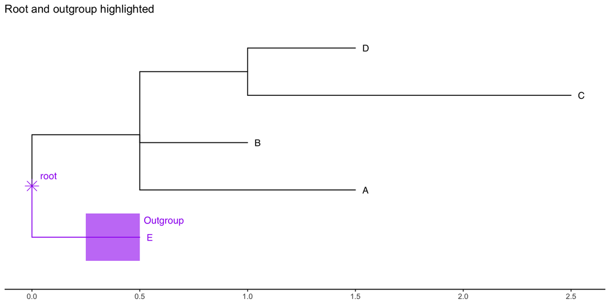

## Notes on Tree Rooting

Conceptually, tree rooting should be done:

- Using a known outgroup (a taxon closely related to, but outside, the study group) to place the ancestor
- Or using midpoint rooting, which sets the root at the midpoint of the longest path between any two taxa

Outgroup rooting provides a more robust evolutionary history, and is generally preferred.

## Types of Trees

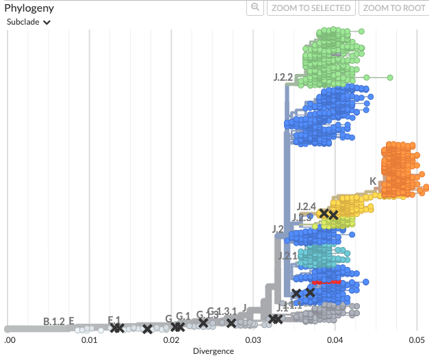

Nextstrain Tree in Divergence Display

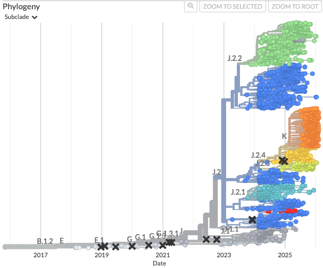

Nextstrain Tree in Time Display

## Molecular Clock Concept

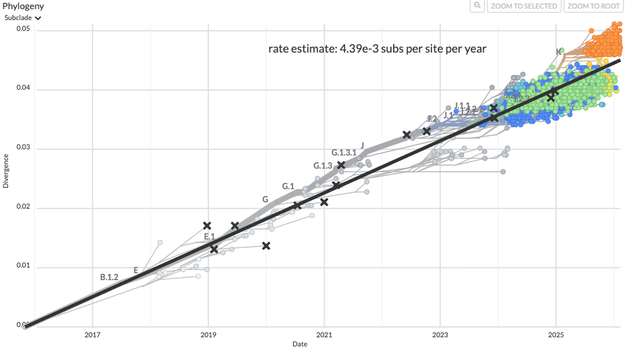

Strict Clock

- Assumes constant rate accross all lineages

Relaxed Clock

- Allows rate variation across branches

## The Concept of Clades

**Clades** are the fundamental grouping of phylogenetic trees. They are defined as a monophyletic group of taxa in a tree that includes a single common ancestor and all its descendants.

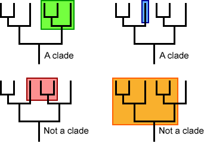

## Clades in Seasonal Influenza

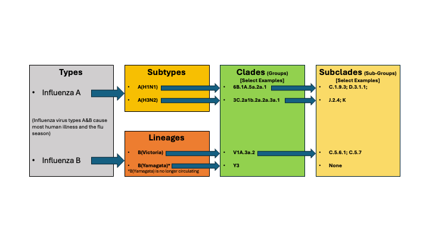

## Clades in Seasonal Influenza (cont.)

The seasonal flu research community recently implemented a [nomenclature and clade proposal system](https://onlinelibrary.wiley.com/doi/10.1111/irv.70230) for tracking important emerging clades. These correspond to the “subclade” designations from [Nextclade](https://clades.nextstrain.org/) outputs.

[figure not shown]

## Clades in Seasonal Influenza (cont.)

Defining a subclade in Nextstrain ([`augur clades` command](https://docs.nextstrain.org/projects/augur/en/stable/usage/cli/clades.html)):

| clade | gene | site | alt |
| --- | --- | --- | --- |
| A | HA1 | 45 | N |
| A | HA1 | 48 | I |
| A | nuc | 473 | T |

| clade | gene | site | alt |
| --- | --- | --- | --- |
| K | clade | J.2.4 |  |
| K | HA1 | 2 | N |
| K | HA1 | 144 | N |
| K | HA1 | 158 | D |
| K | HA1 | 160 | K |
| K | HA1 | 173 | R |

## Clades in Seasonal Influenza (cont.)

Subclade K example:

| clade | gene | site | alt |
| --- | --- | --- | --- |
| K | clade | J.2.4 |  |
| K | HA1 | 2 | N |
| K | HA1 | 144 | N |
| K | HA1 | 158 | D |
| K | HA1 | 160 | K |
| K | HA1 | 173 | R |

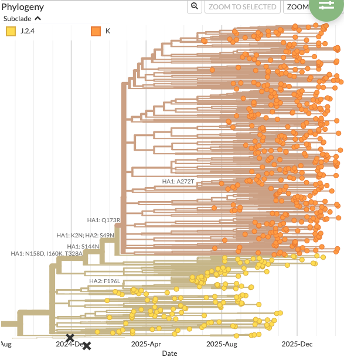

## Subclades vs. Lineages (Pango 🤦)

Influenza subclades are **not** equivalent to [Pango (SARS-CoV-2) lineages](https://web.archive.org/web/20240116214047/https://www.pango.network/how-does-the-system-work/what-are-pango-lineages/).

Pango lineage designations only requirement is a group of viruses having a shared ancestry.

Lineage proposals are through [public submission](https://github.com/cov-lineages/pango-designation/tree/master?tab=readme-ov-file)

This has led to the designation of 5.7K+ lineages. 🤯

## Subclade Proposal Process

Subclade proposal criteria:

1. Size: large groups should have a higher priority for designation.
2. Divergence: the more mutations have accumulated relative to the break point of the parent clade, the higher the priority of a novel clade
3. Specific mutations: Ideally, breakpoints sit on long branches with significant mutation. Such mutations will be better defined for well studied segments/genomes.

Each of these components feeds into the calculation of normalized branch scores across a phylogenetic tree.

A threshold score of 1.0 is set.

## Example of Implementation Using H3N2 HA

```r
library(networkD3)
library(data.tree)
library(htmlwidgets)
library(collapsibleTree)
library(yaml)
library(viridis)

# Create tree via a nested yaml string
yaml <- "
name: A (3C)
A.2 (3C.2):
  B (*A.2.1):
    B.1:
      B.1.1:
      B.1.2:
        B.1.2.1:
          D (*B.1.2.1.2):
        E (*B.1.2.2):
          E.1:
            F (*E.1.1):
              F.1:
                F.1.1:
            G (*E.1.2):
              G.1:
                G.1.1:
                  G.1.1.1:
                  G.1.1.2:
                G.1.2:
                G.1.3:
                  G.1.3.1:
                    J (*G.1.3.1.1):
                      J.1:
                        J.1.1:
                      J.2:
                        J.2.1:
                        J.2.2:
                        J.2.3:
                        J.2.4:
                          K (*J.2.4.1):
                        J.2.5:
                      J.3:
                      J.4:
                  G.1.3.2:
              G.2:
                G.2.1:
                G.2.2:
              G.3:
              G.4:
          E.2:
  B.2:
  B.3:
  B.4:
A.3 (3C.3):
  C (*A.3.1):
    C.1
  A.3.2:
"

# Load the yaml tree into a list
h3List <- yaml.load(yaml)

# Transform into a data.tree object
h3Node <- as.Node(h3List, interpretNullAsList = TRUE)

# Assign a vector of colors for nodes
h3Colors <- viridis::turbo(h3Node$totalCount)

# Assign colors to tree nodes
i <- 1
h3Node$Do(function(node) {
  node$color <- h3Colors[i]
  i <<- i + 1
})

# Display collapsible tree
collapsibleTree(h3Node,
                fill = "color",
                tooltip = TRUE)
```

[interactive chart not shown]

# Section 2: Tree Building Overview

Quick break.

## Phylogenetic Tree Building Steps

```
flowchart TD
    A[Sequence selection and filtering]
    style A text-align:center
    B[Multiple sequence alignment]
    style B text-align:center
    C[Model selection]
    style C text-align:center
    D[Tree inference]
    style D text-align:center
    E[Tree evaluation and visualization]
    style E text-align:center

    A -->  |The data that is <br/> included is **important**| B
    B --> C
    C --> |Also important for <br/> proper tree contruction| D
    D --> E
```

## Sequence Selection

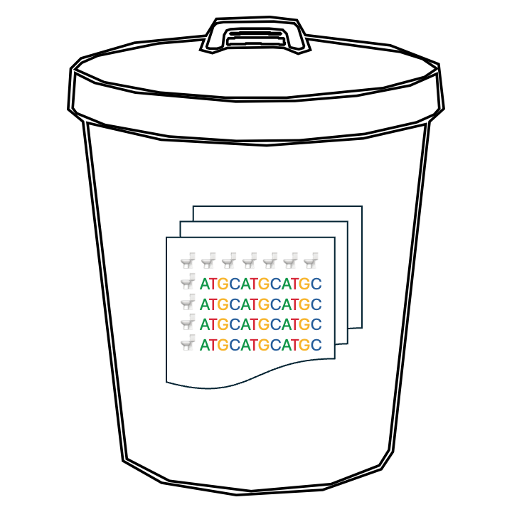

Garbage in

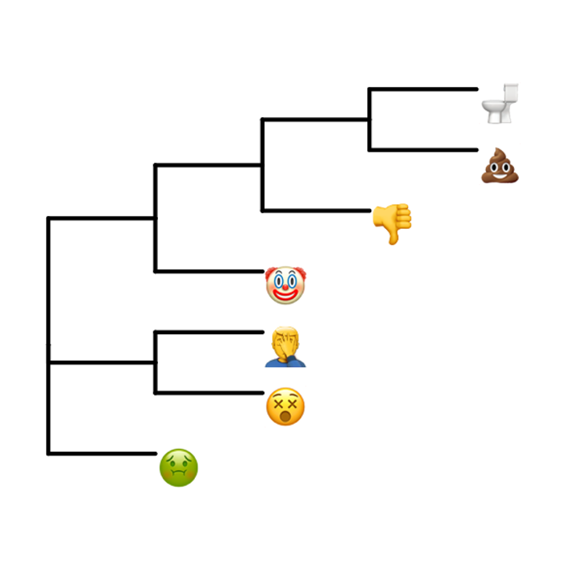

Garbage out

## Sequence Selection

When starting the process of building a tree:

- Consensus sequence data quality (not just NGS coverage)
- What is the question you are trying to address?
  - Global surveillence?
  - Targeted regional analysis?
  - Country specific questions?
  - Timing of a newly emerged variant?
    - *Be especially careful here. This requires intensive analysis and scrutiny. Understand the limitations of analysis.*

## Multiple Sequence Alignment (MSA)

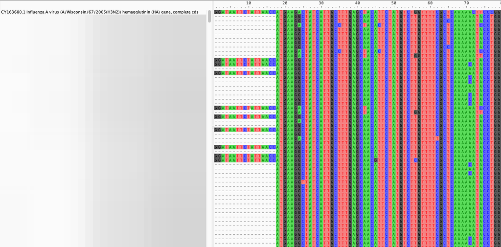

## MSA Algorithms

Examples of MSA software:

- [CLUSTAL Omega](https://www.ebi.ac.uk/jdispatcher/msa/clustalo)
- [MAFFT](https://mafft.cbrc.jp/alignment/server/index.html)
- [MUSCLE](https://github.com/rcedgar/muscle)
- [**nextclade** aligner (previously nextalign)](https://github.com/nextstrain/nextclade?tab=readme-ov-file)

## Model Selection

Assuming nucleotide sequence data as input:

- Jukes-Cantor (simplest model)<sup>1</sup>
- HKY
- TN93
- GTR (Model implemented in Nextstrain flu pipelines)
[^2]: Model references can be found [**here**](https://onlinelibrary.wiley.com/doi/full/10.1111/irv.70230)

## Tree Inference - Algorithms

Distance Based:

- Neighbor joining
- UPGMA

Character Based:

- Maximum Parsimony
- Maximum Likelihood (used in Nextstrain pipelines)
- Bayesian Inference

## Tree Inference - Software

- [MEGA](https://www.megasoftware.net/)
- [RAxML](https://cme.h-its.org/exelixis/web/software/raxml/)
- [FastTree](https://morgannprice.github.io/fasttree/)
- [IQ-TREE (Nextstrain Default)](https://iqtree.github.io/)
- cmaple (Standalone program and within IQ-TREE using  
  `--pathogen` flag)

## Tree Evaluation and Visualization

- [Nextstrain (auspice)](https://docs.nextstrain.org/projects/auspice/en/stable/)
- [auspice.us (browser based auspice)](https://auspice.us/)
- [IcyTree (browser based)](https://icytree.org/)
- [FigTree](https://tree.bio.ed.ac.uk/software/figtree/)
- [ITOL](https://itol.embl.de/)
- [Dendroscope](https://uni-tuebingen.de/fakultaeten/mathematisch-naturwissenschaftliche-fakultaet/fachbereiche/informatik/lehrstuehle/algorithms-in-bioinformatics/software/dendroscope/)
- [archaeopteryx](https://www.phylosoft.org/archaeopteryx/)
- Programmatic libraries:
  - [ETE Toolkit](https://etetoolkit.org/)
  - [ggtree](https://guangchuangyu.github.io/software/ggtree/)

## Intro to Nextstrain

[Nextstrain](https://docs.nextstrain.org/en/latest/learn/about.html#) is an open source toolkit for analyzing and visualizing pathogen genomic data.

The two core parts of Nextstrain are:

- Augur (modular bioinformatics toolkit)
- Auspice (browser based vizualization)

## Nextstrain process overview

```
flowchart TB
    subgraph Inputs
        direction LR
        A[sequences.fasta]
        B[metadata.tsv]
    end

    subgraph Augur
    direction LR
        C(filter)
        D(align)
        E(tree)
        F(refine)
        G(export)
        C --> D
        D --> E
        E --> F
        F --> G
    end

    Inputs --> Augur
    Augur --> H[Build Dataset]
    H --> I[Auspice]

     %% Styling
    classDef input fill:#ffffff,stroke:#555,rx:12,ry:12;
    classDef step fill:#bfe3ff,stroke:#3b82c4,rx:14,ry:14;
    classDef output fill:#ffffff,stroke:#555,rx:12,ry:12;
    classDef final fill:#b9f5b0,stroke:#2e7d32,rx:14,ry:14;

    class A,B input;
    class C,D,E,F,G step;
    class H output;
    class I final;
```

# Section 3: Nextstrain Build Exercise

Click on the following [link](https://github.com/nhassell/seasonal-flu-demo/blob/master/demo.md#customizing-basic-build-elements) which will direct you to the exercise we will be going through together.

# Section 4: Overview of Nextstrain Features and Navigation

We’ll go over features of your build and navigate it together.

# Section 5: Communicating Results Using Nextstrain Narratives

## Introduction to Nextstrain Narratives

[Nextstrain narratives](https://docs.nextstrain.org/en/latest/tutorials/narratives-how-to-write.html) are markdown (.md) files that allow the communication of results interactively in a slide-like format.

Click on the link above for detailed documentation on narratives.

For an example of a narrative, take a look at the [Twenty years of West Nile virus](https://nextstrain.org/narratives/twenty-years-of-WNV) narrative.

## Components of a Narrative: Header

Open the example narrative file `/profiles/gisaid/custom.md` in VS Code.

At the top of the file is the narrative header:

```markdown
---
title: Custom Local Hosted Narrative
authors: Norman Hassell
date: "2026-03-02"
dataset: "https://nextstrain.org/custom/h3n2/ha"
abstract: "
Custom narrative of custom build
"
---
```

For local builds, you will have the prefix `https://nextstrain.org` followed by your build file name with underscores replaced by the `/` character (ie. `custom_h3n2_ha.json` dataset becomes `https://nextstrain.org/custom/h3n2/ha`)

## Components of a Narrative: Header (Result)

[figure not shown]

## Components of a Narrative: Basic Slides

Basic slides are set up by providing copied links as first level headers:

[figure not shown]

```markdown
# [Custom Dataset Slide](https://nextstrain.org/custom/h3n2/ha?d=tree,map,frequencies&f_sample_type=sample&p=grid)

Example of a basic slide view.

The slide is filtered to a "Sample Type" of "sample".
```

Copy the end of the link and add the prefix of `https://nextstrain.org/`

## Components of a Narrative: Basic Slides (Result)

[figure not shown]

## Components of a Narrative: Animations

Timeline animations can be used in narratives by copying the link associated with the animation.

The link will briefly show after clicking the “Play ▶️” button underneath the “Date Range” toolbar.

```markdown
# [Custom Dataset Animations](https://nextstrain.org/custom/h3n2/ha?animate=2024-06-04,2025-12-20,0,0,30000&d=map&f_sample_type=sample&p=full)

Animations can be captured.
```

## Components of a Narrative: Animations (Result)

[figure not shown]

## Components of a Narrative: Images

Images can be embedded into the narrative sidebar or main display from direct links or [base64 conversion](https://www.base64-image.de/).

````markdown
# [Image Embedding](https://nextstrain.org/custom/h3n2/ha)

Images can be embedded from the web in the side panel.

![](https://www.esrf.fr/files/live/sites/www/files/news/general-old/general-2009/Influenza-Virus.jpg)

```auspiceMainDisplayMarkdown
### Or in the main body display via the `auspiceMainDisplayMarkdown` section.

For main body markdown display.

![Flu](https://www.embl.org/news/wp-content/uploads/2020/04/INFLUENZA_EDIT.jpg)
```
````

Note the usage of the `auspiceMainDisplayMarkdown` block to have markdown for the main narrative display.

## Components of a Narrative: Images (Results)

[figure not shown]

## Narratives Continued

Normal features of markdown such as:

- Tables
- Lists
- Text formatting
- HTML embedding

Can all be used in both the narrative side panel and main display.

Again, the main display requires the `auspiceMainDisplayMarkdown` block for use.

## Narrative Exercise

Before moving on to the exercise open a new terminal in the  
`seasonal-flu-demo` folder and enter into a new nextstrain shell session:

```bash
nextstrain shell .
```

Then, run another build using the following command:

```bash
nextstrain build . --configfile profiles/gisaid/custom_gisaid_global.yaml
```

Repeat this process for a third build.

Open a new terminal, enter a nextstrain shell, and execute the following:

```bash
nextstrain build . --configfile profiles/gisaid/custom_gisaid_norefs.yaml
```

## Narrative Exercise

Develop a narrative walking through your current build focusing on viruses circulating in Oceania/Australia (`custom_h3n2_ha`).

- What were the most prominent subclades for samples?
- What subclade is exhibiting the highest local branching index (LBI)?
- From the identified subclade with the highest LBI, what is the estimated emergence date and range?
- What regions is this subclade present in?
- What is the rate calculation for the tree overall vs. the rate for the subclade?
- Are there any reagent viruses in this subclade? Highlight them.
- Add another narrative slide of your choice, highlighting something you’ve found.
- Close out your narrative with a summary slide.

# Section 6: Build Comparisons

We’ll take some time to compare the three different builds we’ve created. To address caveats of sampling.